# Ames Housing Price Prediction Analysis

MTTS Capstone Project - Room 3

Authors

Priyanshi Agarwal

Aduvet Raizada

Sanya Khurana

Prince Chaudhari

Published

February 9, 2026

**Supervised by:** Mr. Manoj Thakur

# 1 Executive Summary

This capstone project analyzes the Ames Housing Dataset to predict residential property sale prices. The dataset contains 1,460 observations with 79 explanatory variables describing physical, locational, and qualitative attributes of homes in Ames, Iowa.

# 2 Introduction

## 2.1 Objective

The goal of this study is to analyze housing data and understand the factors influencing house prices. The response variable is SalePrice.

## 2.2 Research Questions

1. What is the distribution of SalePrice?
2. Which variables show strong relationships with SalePrice?
3. Are there missing values and outliers that may affect modeling?

## 2.3 Dataset Overview

This data contains residential home sales in Ames with 79 explanatory variables (excluding ID) describing physical, locational and qualitative attributes of houses.

# 3 Setup and Data Loading

```r
library(tidyverse)
library(e1071)
library(skimr)
library(car)
library(caret)

# Load data
train_dt <- read.csv("train.csv", header = TRUE)
test_dt  <- read.csv("test.csv",  header = TRUE)

# Combine for preprocessing
full_dt = bind_rows(train_dt, test_dt)

# Display dimensions
dim(train_dt)
```

```
[1] 1460   81
```

```r
dim(test_dt)
```

```
[1] 1459   80
```

# 4 Variable Classification

```r
# Define categorical variables
categorical_vars = c("MSSubClass",
                     names(full_dt)[sapply(full_dt, is.character)],
                     "OverallQual", "OverallCond")

# Ordinal categorical variables (qualitative but ordered)
ordinal_vars <- c(
  "ExterQual", "ExterCond",
  "BsmtQual", "BsmtCond", "BsmtExposure",
  "BsmtFinType1", "BsmtFinType2",
  "HeatingQC", "KitchenQual",
  "FireplaceQu", "GarageQual", "GarageCond",
  "PoolQC","OverallQual", "OverallCond"
)

# Nominal categorical variables
nominal_vars <- categorical_vars[!categorical_vars %in% ordinal_vars]

# Quantitative ordinal variables
numeric_ordinal_vars <- c("OverallQual", "OverallCond")

# Non-numeric ordinal variables
non_num_ord_vars <- c("ExterQual", "ExterCond",
                      "BsmtQual", "BsmtCond", "BsmtExposure",
                      "BsmtFinType1", "BsmtFinType2",
                      "HeatingQC", "KitchenQual",
                      "FireplaceQu", "GarageQual", "GarageCond",
                      "PoolQC")
```

**Interpretation**: Ordinal variables represent ordered qualitative information. Although sometimes encoded numerically, they do not represent continuous quantities. Treating ordinal variables as numerical may introduce incorrect assumptions of linearity.

# 5 Data Preprocessing

## 5.1 Handling Missing Values

### 5.1.1 Variables where NA means “feature absent”

```r
absence_vars <- c("FireplaceQu","GarageQual","GarageCond",
                  "BsmtQual","BsmtCond","BsmtExposure",
                  "BsmtFinType1","BsmtFinType2","PoolQC","MiscFeature",
                  "Alley","Fence","GarageType","GarageFinish","MasVnrType")

full_dt[absence_vars] <- lapply(full_dt[absence_vars], function(x) {
  x <- as.character(x)
  x[is.na(x)] <- "No"
  x
})
```

### 5.1.2 Numeric variables with NA indicating non-existence

```r
absence_num_vars <- c("GarageYrBlt", "MasVnrArea", "LotFrontage")

for (v in absence_num_vars) {
  full_dt[[paste0("Has_", v)]] <- ifelse(is.na(full_dt[[v]]), 0, 1)
  full_dt[[v]][is.na(full_dt[[v]])] <- 0
}
```

**Rationale**: For numeric variables where NA indicates non-existence rather than missing measurement, indicator variables were introduced to distinguish presence from magnitude, thereby avoiding distortion of the numeric scale.

### 5.1.3 Electrical System

```r
full_dt$Electrical <- as.character(full_dt$Electrical)
full_dt$Electrical[is.na(full_dt$Electrical)] <- "Unknown"
full_dt$Electrical <- factor(full_dt$Electrical)
```

**Rationale**: Electrical is treated as a nominal categorical variable. Missing values do not indicate absence of electricity but unknown classification; therefore, an explicit ‘Unknown’ category is introduced.

## 5.2 Ordinal Variable Encoding

```r
# Convert MSSubClass to factor
full_dt$MSSubClass <- as.factor(full_dt$MSSubClass)

# Explicit level ordering for qualitative ordinal variables
qual_levels <- list(
  ExterQual    = c("No","Po","Fa","TA","Gd","Ex"),
  ExterCond    = c("No","Po","Fa","TA","Gd","Ex"),
  BsmtQual     = c("No","Po","Fa","TA","Gd","Ex"),
  BsmtCond     = c("No","Po","Fa","TA","Gd","Ex"),
  BsmtExposure = c("No","Mn","Av","Gd"),
  BsmtFinType1 = c("No","Unf","LwQ","Rec","BLQ","ALQ","GLQ"),
  BsmtFinType2 = c("No","Unf","LwQ","Rec","BLQ","ALQ","GLQ"),
  HeatingQC    = c("Po","Fa","TA","Gd","Ex"),
  KitchenQual  = c("Po","Fa","TA","Gd","Ex"),
  FireplaceQu  = c("No","Po","Fa","TA","Gd","Ex"),
  GarageQual   = c("No","Po","Fa","TA","Gd","Ex"),
  GarageCond   = c("No","Po","Fa","TA","Gd","Ex"),
  PoolQC       = c("No","Fa","TA","Gd","Ex")
)

for (v in names(qual_levels)) {
  full_dt[[v]] <- factor(
    full_dt[[v]],
    levels = qual_levels[[v]],
    ordered = TRUE
  )
}
```

## 5.3 Split back to train and test

```r
train_dt <- full_dt[1:nrow(train_dt), ]
test_dt  <- full_dt[(nrow(train_dt)+1):nrow(full_dt), ]

# Binary indicators
binary_vars <- grep("^Has_", names(train_dt), value = TRUE)

# Continuous numeric variables
numeric_continuous <- names(train_dt)[
  sapply(train_dt, is.numeric) &
    !(names(train_dt) %in% c(
      binary_vars,
      numeric_ordinal_vars,
      "SalePrice"
    ))
]
```

## 5.4 Variable Type Summary

```r
variable_type_summary <- data.frame(
  Variable = names(train_dt),
  Type = case_when(
    names(train_dt) %in% binary_vars ~ "Binary (Indicator)",
    names(train_dt) %in% nominal_vars ~ "Categorical (Nominal)",
    names(train_dt) %in% ordinal_vars ~ "Categorical (Ordinal)",
    names(train_dt) %in% numeric_ordinal_vars ~ "Numeric (Ordinal)",
    names(train_dt) %in% numeric_continuous ~ "Continuous",
    names(train_dt) == "SalePrice" ~ "Response Variable",
    TRUE ~ "Other"
  )
)

table(variable_type_summary$Type)
```

```
   Binary (Indicator) Categorical (Nominal) Categorical (Ordinal)
                    3                    31                    15
           Continuous     Response Variable
                   34                     1
```

# 6 Exploratory Data Analysis

## 6.1 Response Variable Analysis

### 6.1.1 Summary Statistics

```r
summary(train_dt$SalePrice)
```

```
   Min. 1st Qu.  Median    Mean 3rd Qu.    Max.
  34900  129975  163000  180921  214000  755000
```

```r
skim(train_dt)
```

Data summary

| Name | train_dt |
| --- | --- |
| Number of rows | 1460 |
| Number of columns | 84 |
| _______________________ |  |
| Column type frequency: |  |
| character | 29 |
| factor | 15 |
| numeric | 40 |
| ________________________ |  |
| Group variables | None |

**Variable type: character**

| skim_variable | n_missing | complete_rate | min | max | empty | n_unique | whitespace |
| --- | --- | --- | --- | --- | --- | --- | --- |
| MSZoning | 0 | 1 | 2 | 7 | 0 | 5 | 0 |
| Street | 0 | 1 | 4 | 4 | 0 | 2 | 0 |
| Alley | 0 | 1 | 2 | 4 | 0 | 3 | 0 |
| LotShape | 0 | 1 | 3 | 3 | 0 | 4 | 0 |
| LandContour | 0 | 1 | 3 | 3 | 0 | 4 | 0 |
| Utilities | 0 | 1 | 6 | 6 | 0 | 2 | 0 |
| LotConfig | 0 | 1 | 3 | 7 | 0 | 5 | 0 |
| LandSlope | 0 | 1 | 3 | 3 | 0 | 3 | 0 |
| Neighborhood | 0 | 1 | 5 | 7 | 0 | 25 | 0 |
| Condition1 | 0 | 1 | 4 | 6 | 0 | 9 | 0 |
| Condition2 | 0 | 1 | 4 | 6 | 0 | 8 | 0 |
| BldgType | 0 | 1 | 4 | 6 | 0 | 5 | 0 |
| HouseStyle | 0 | 1 | 4 | 6 | 0 | 8 | 0 |
| RoofStyle | 0 | 1 | 3 | 7 | 0 | 6 | 0 |
| RoofMatl | 0 | 1 | 4 | 7 | 0 | 8 | 0 |
| Exterior1st | 0 | 1 | 5 | 7 | 0 | 15 | 0 |
| Exterior2nd | 0 | 1 | 5 | 7 | 0 | 16 | 0 |
| MasVnrType | 0 | 1 | 2 | 7 | 0 | 5 | 0 |
| Foundation | 0 | 1 | 4 | 6 | 0 | 6 | 0 |
| Heating | 0 | 1 | 4 | 5 | 0 | 6 | 0 |
| CentralAir | 0 | 1 | 1 | 1 | 0 | 2 | 0 |
| Functional | 0 | 1 | 3 | 4 | 0 | 7 | 0 |
| GarageType | 0 | 1 | 2 | 7 | 0 | 7 | 0 |
| GarageFinish | 0 | 1 | 2 | 3 | 0 | 4 | 0 |
| PavedDrive | 0 | 1 | 1 | 1 | 0 | 3 | 0 |
| Fence | 0 | 1 | 2 | 5 | 0 | 5 | 0 |
| MiscFeature | 0 | 1 | 2 | 4 | 0 | 5 | 0 |
| SaleType | 0 | 1 | 2 | 5 | 0 | 9 | 0 |
| SaleCondition | 0 | 1 | 6 | 7 | 0 | 6 | 0 |

**Variable type: factor**

| skim_variable | n_missing | complete_rate | ordered | n_unique | top_counts |
| --- | --- | --- | --- | --- | --- |
| MSSubClass | 0 | 1 | FALSE | 15 | 20: 536, 60: 299, 50: 144, 120: 87 |
| ExterQual | 0 | 1 | TRUE | 4 | TA: 906, Gd: 488, Ex: 52, Fa: 14 |
| ExterCond | 0 | 1 | TRUE | 5 | TA: 1282, Gd: 146, Fa: 28, Ex: 3 |
| BsmtQual | 0 | 1 | TRUE | 5 | TA: 649, Gd: 618, Ex: 121, No: 37 |
| BsmtCond | 0 | 1 | TRUE | 5 | TA: 1311, Gd: 65, Fa: 45, No: 37 |
| BsmtExposure | 0 | 1 | TRUE | 4 | No: 991, Av: 221, Gd: 134, Mn: 114 |
| BsmtFinType1 | 0 | 1 | TRUE | 7 | Unf: 430, GLQ: 418, ALQ: 220, BLQ: 148 |
| BsmtFinType2 | 0 | 1 | TRUE | 7 | Unf: 1256, Rec: 54, LwQ: 46, No: 38 |
| HeatingQC | 0 | 1 | TRUE | 5 | Ex: 741, TA: 428, Gd: 241, Fa: 49 |
| Electrical | 0 | 1 | FALSE | 6 | SBr: 1334, Fus: 94, Fus: 27, Fus: 3 |
| KitchenQual | 0 | 1 | TRUE | 4 | TA: 735, Gd: 586, Ex: 100, Fa: 39 |
| FireplaceQu | 0 | 1 | TRUE | 6 | No: 690, Gd: 380, TA: 313, Fa: 33 |
| GarageQual | 0 | 1 | TRUE | 6 | TA: 1311, No: 81, Fa: 48, Gd: 14 |
| GarageCond | 0 | 1 | TRUE | 6 | TA: 1326, No: 81, Fa: 35, Gd: 9 |
| PoolQC | 0 | 1 | TRUE | 4 | No: 1453, Gd: 3, Fa: 2, Ex: 2 |

**Variable type: numeric**

| skim_variable | n_missing | complete_rate | mean | sd | p0 | p25 | p50 | p75 | p100 | hist |
| --- | --- | --- | --- | --- | --- | --- | --- | --- | --- | --- |
| Id | 0 | 1 | 730.50 | 421.61 | 1 | 365.75 | 730.5 | 1095.25 | 1460 | ▇▇▇▇▇ |
| LotFrontage | 0 | 1 | 57.62 | 34.66 | 0 | 42.00 | 63.0 | 79.00 | 313 | ▇▇▁▁▁ |
| LotArea | 0 | 1 | 10516.83 | 9981.26 | 1300 | 7553.50 | 9478.5 | 11601.50 | 215245 | ▇▁▁▁▁ |
| OverallQual | 0 | 1 | 6.10 | 1.38 | 1 | 5.00 | 6.0 | 7.00 | 10 | ▁▂▇▅▁ |
| OverallCond | 0 | 1 | 5.58 | 1.11 | 1 | 5.00 | 5.0 | 6.00 | 9 | ▁▁▇▅▁ |
| YearBuilt | 0 | 1 | 1971.27 | 30.20 | 1872 | 1954.00 | 1973.0 | 2000.00 | 2010 | ▁▂▃▆▇ |
| YearRemodAdd | 0 | 1 | 1984.87 | 20.65 | 1950 | 1967.00 | 1994.0 | 2004.00 | 2010 | ▅▂▂▃▇ |
| MasVnrArea | 0 | 1 | 103.12 | 180.73 | 0 | 0.00 | 0.0 | 164.25 | 1600 | ▇▁▁▁▁ |
| BsmtFinSF1 | 0 | 1 | 443.64 | 456.10 | 0 | 0.00 | 383.5 | 712.25 | 5644 | ▇▁▁▁▁ |
| BsmtFinSF2 | 0 | 1 | 46.55 | 161.32 | 0 | 0.00 | 0.0 | 0.00 | 1474 | ▇▁▁▁▁ |
| BsmtUnfSF | 0 | 1 | 567.24 | 441.87 | 0 | 223.00 | 477.5 | 808.00 | 2336 | ▇▅▂▁▁ |
| TotalBsmtSF | 0 | 1 | 1057.43 | 438.71 | 0 | 795.75 | 991.5 | 1298.25 | 6110 | ▇▃▁▁▁ |
| X1stFlrSF | 0 | 1 | 1162.63 | 386.59 | 334 | 882.00 | 1087.0 | 1391.25 | 4692 | ▇▅▁▁▁ |
| X2ndFlrSF | 0 | 1 | 346.99 | 436.53 | 0 | 0.00 | 0.0 | 728.00 | 2065 | ▇▃▂▁▁ |
| LowQualFinSF | 0 | 1 | 5.84 | 48.62 | 0 | 0.00 | 0.0 | 0.00 | 572 | ▇▁▁▁▁ |
| GrLivArea | 0 | 1 | 1515.46 | 525.48 | 334 | 1129.50 | 1464.0 | 1776.75 | 5642 | ▇▇▁▁▁ |
| BsmtFullBath | 0 | 1 | 0.43 | 0.52 | 0 | 0.00 | 0.0 | 1.00 | 3 | ▇▆▁▁▁ |
| BsmtHalfBath | 0 | 1 | 0.06 | 0.24 | 0 | 0.00 | 0.0 | 0.00 | 2 | ▇▁▁▁▁ |
| FullBath | 0 | 1 | 1.57 | 0.55 | 0 | 1.00 | 2.0 | 2.00 | 3 | ▁▇▁▇▁ |
| HalfBath | 0 | 1 | 0.38 | 0.50 | 0 | 0.00 | 0.0 | 1.00 | 2 | ▇▁▅▁▁ |
| BedroomAbvGr | 0 | 1 | 2.87 | 0.82 | 0 | 2.00 | 3.0 | 3.00 | 8 | ▁▇▂▁▁ |
| KitchenAbvGr | 0 | 1 | 1.05 | 0.22 | 0 | 1.00 | 1.0 | 1.00 | 3 | ▁▇▁▁▁ |
| TotRmsAbvGrd | 0 | 1 | 6.52 | 1.63 | 2 | 5.00 | 6.0 | 7.00 | 14 | ▂▇▇▁▁ |
| Fireplaces | 0 | 1 | 0.61 | 0.64 | 0 | 0.00 | 1.0 | 1.00 | 3 | ▇▇▁▁▁ |
| GarageYrBlt | 0 | 1 | 1868.74 | 453.70 | 0 | 1958.00 | 1977.0 | 2001.00 | 2010 | ▁▁▁▁▇ |
| GarageCars | 0 | 1 | 1.77 | 0.75 | 0 | 1.00 | 2.0 | 2.00 | 4 | ▁▃▇▂▁ |
| GarageArea | 0 | 1 | 472.98 | 213.80 | 0 | 334.50 | 480.0 | 576.00 | 1418 | ▂▇▃▁▁ |
| WoodDeckSF | 0 | 1 | 94.24 | 125.34 | 0 | 0.00 | 0.0 | 168.00 | 857 | ▇▂▁▁▁ |
| OpenPorchSF | 0 | 1 | 46.66 | 66.26 | 0 | 0.00 | 25.0 | 68.00 | 547 | ▇▁▁▁▁ |
| EnclosedPorch | 0 | 1 | 21.95 | 61.12 | 0 | 0.00 | 0.0 | 0.00 | 552 | ▇▁▁▁▁ |
| X3SsnPorch | 0 | 1 | 3.41 | 29.32 | 0 | 0.00 | 0.0 | 0.00 | 508 | ▇▁▁▁▁ |
| ScreenPorch | 0 | 1 | 15.06 | 55.76 | 0 | 0.00 | 0.0 | 0.00 | 480 | ▇▁▁▁▁ |
| PoolArea | 0 | 1 | 2.76 | 40.18 | 0 | 0.00 | 0.0 | 0.00 | 738 | ▇▁▁▁▁ |
| MiscVal | 0 | 1 | 43.49 | 496.12 | 0 | 0.00 | 0.0 | 0.00 | 15500 | ▇▁▁▁▁ |
| MoSold | 0 | 1 | 6.32 | 2.70 | 1 | 5.00 | 6.0 | 8.00 | 12 | ▃▆▇▃▃ |
| YrSold | 0 | 1 | 2007.82 | 1.33 | 2006 | 2007.00 | 2008.0 | 2009.00 | 2010 | ▇▇▇▇▅ |
| SalePrice | 0 | 1 | 180921.20 | 79442.50 | 34900 | 129975.00 | 163000.0 | 214000.00 | 755000 | ▇▅▁▁▁ |
| Has_GarageYrBlt | 0 | 1 | 0.94 | 0.23 | 0 | 1.00 | 1.0 | 1.00 | 1 | ▁▁▁▁▇ |
| Has_MasVnrArea | 0 | 1 | 0.99 | 0.07 | 0 | 1.00 | 1.0 | 1.00 | 1 | ▁▁▁▁▇ |
| Has_LotFrontage | 0 | 1 | 0.82 | 0.38 | 0 | 1.00 | 1.0 | 1.00 | 1 | ▂▁▁▁▇ |

### 6.1.2 Distribution of SalePrice

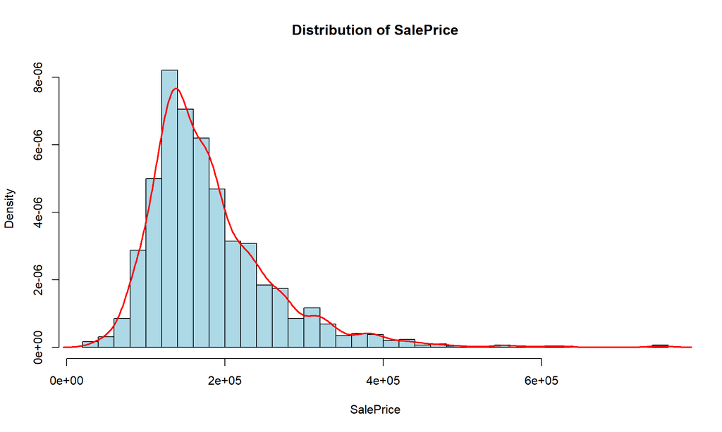

```r
hist(
  train_dt$SalePrice,
  breaks = 40,
  probability = TRUE,
  col = "lightblue",
  main = "Distribution of SalePrice",
  xlab = "SalePrice"
)

lines(
  density(train_dt$SalePrice, na.rm = TRUE),
  col = "red",
  lwd = 2
)
```

### 6.1.3 Q-Q Plot

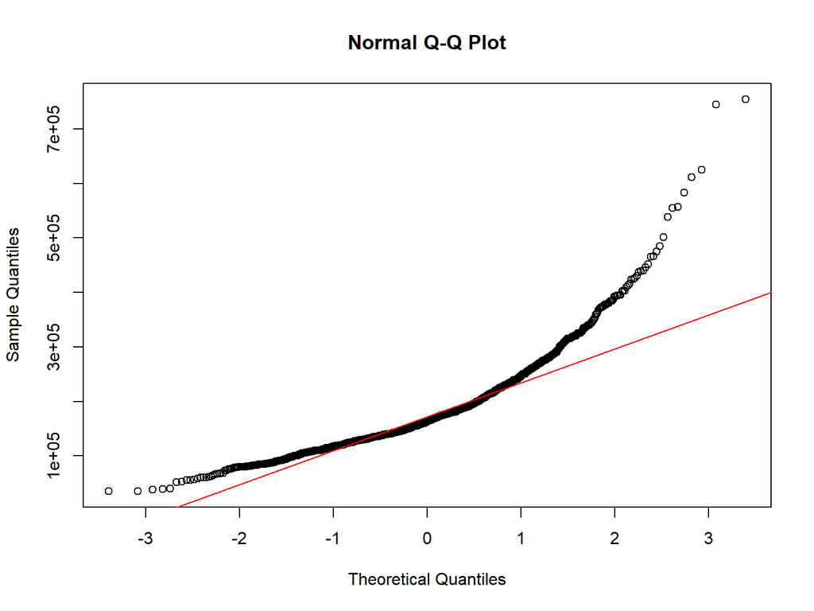

```r
qqnorm(train_dt$SalePrice)
qqline(train_dt$SalePrice, col = "red")
```

### 6.1.4 Skewness and Kurtosis

```r
skewness(train_dt$SalePrice, na.rm = TRUE)
```

```
[1] 1.879009
```

```r
kurtosis(train_dt$SalePrice, na.rm = TRUE)
```

```
[1] 6.496789
```

**Observation and Interpretation**:

1. The SalePrice distribution is heavily right-skewed, indicating that most houses are concentrated in a moderate price range, while a small number of high-priced houses form a long upper tail.
2. The Q–Q plot shows clear deviation from normality in the upper tail, confirming violation of linear regression assumptions on the original scale.
3. This motivates the use of a log transformation to stabilize variance and improve model validity.
4. The distribution has heavy tails and is more sharply peaked at the center compared to a normal distribution.

## 6.2 Log Transformation

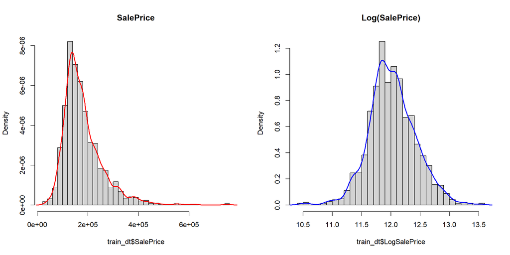

```r
# Create log-transformed variable
train_dt$LogSalePrice <- log1p(train_dt$SalePrice)

# Compare distributions
par(mfrow = c(1,2))

hist(train_dt$SalePrice,
     breaks = 40,
     probability = TRUE,
     main = "SalePrice",
     col = "lightgray")
lines(density(train_dt$SalePrice), col = "red", lwd = 2)

hist(train_dt$LogSalePrice,
     breaks = 40,
     probability = TRUE,
     main = "Log(SalePrice)",
     col = "lightgray")
lines(density(train_dt$LogSalePrice), col = "blue", lwd = 2)
```

```r
par(mfrow = c(1,1))
```

**Reasoning**:

-To address skewness and stabilize variance, a logarithmic transformation was applied to SalePrice. The transformed variable shows a distribution closer to normal, improving model performance and interpretability.

## 6.3 Outlier Detection

### 6.3.1 Original Scale Outliers

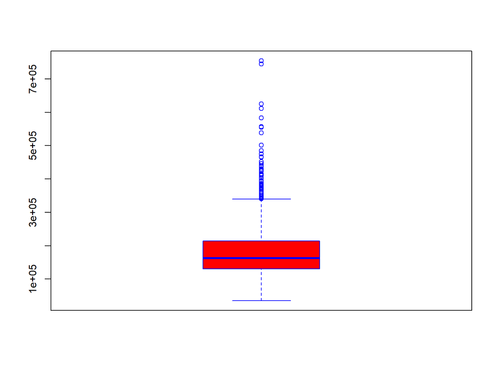

```r
Sale_box <- boxplot(train_dt$SalePrice,
        range = 1.5,
        horizontal = FALSE,
        varwidth = TRUE,
        notch = FALSE,
        outline = TRUE,
        boxwex = 0.3,
        border = "blue",
        col = "red")
```

```r
Sale_outlier <- Sale_box$out
outlier_rows <- which(train_dt$SalePrice %in% Sale_outlier)
```

**NOTE**: The remaining outliers after transformation correspond to genuinely extreme market cases, such as luxury houses in premium neighborhoods and very low-priced properties in older areas. These observations are retained because they represent real market behavior rather than data errors.

### 6.3.2 Log Scale Outliers

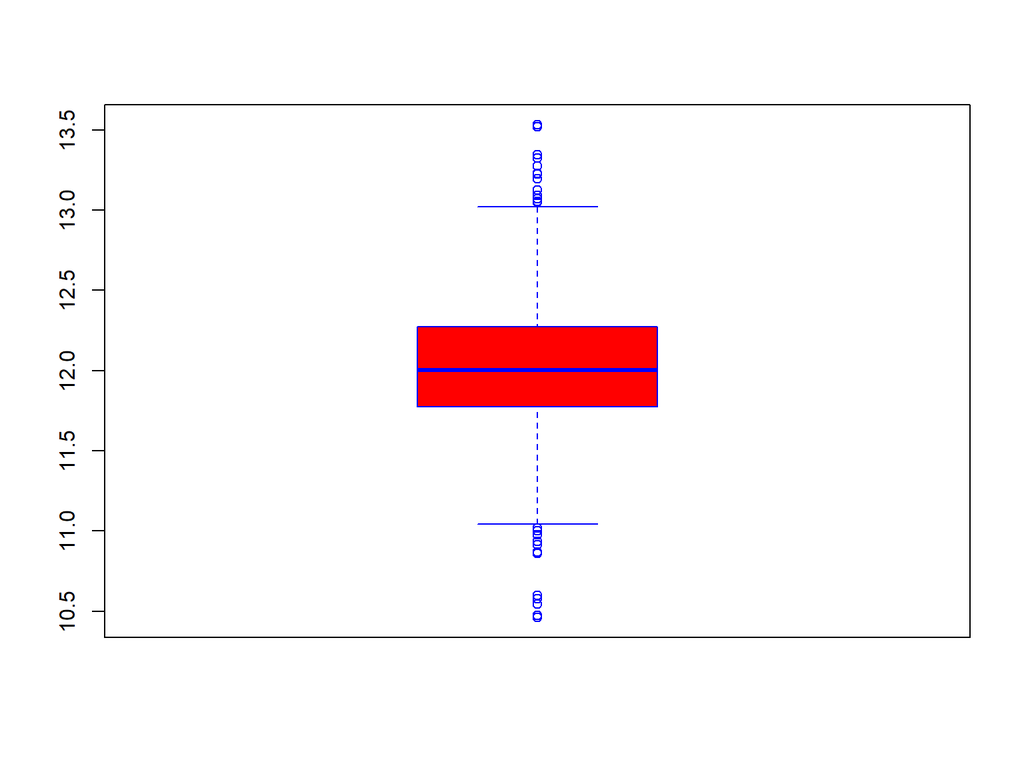

```r
# Log transform first to see "true" statistical anomalies
log_price <- log(train_dt$SalePrice)

Sale_box <- boxplot(log_price,
                   range = 1.5,
                   horizontal = FALSE,
                   varwidth = TRUE,
                   notch = FALSE,
                   outline = TRUE,
                   boxwex = 0.3,
                   border = "blue",
                   col = "red")
```

```r
Sale_outlier_logs <- Sale_box$out
outlier_values <- train_dt$SalePrice[log_price %in% Sale_outlier_logs]
outlier_rows <- which(train_dt$SalePrice %in% outlier_values)

# View the full rows for those outliers
train_dt[outlier_rows, c("SalePrice", "OverallQual", "GrLivArea", "Neighborhood")]
```

```
     SalePrice OverallQual GrLivArea Neighborhood
31       40000           4      1317       IDOTRR
179     501837           9      2234      StoneBr
186     475000          10      3608      OldTown
376      61000           1       904      Edwards
411      60000           5      1276      Edwards
441     555000          10      2402      NridgHt
496      34900           4       720       IDOTRR
534      39300           1       334      BrkSide
637      60000           2       800      BrkSide
692     755000          10      4316      NoRidge
706      55000           4      1092       IDOTRR
711      52000           3       729      BrkSide
770     538000           8      3279      StoneBr
799     485000           9      3140      NridgHt
804     582933           9      2822      NridgHt
813      55993           5      1044       IDOTRR
899     611657           9      2364      NridgHt
917      35311           2       480       IDOTRR
969      37900           3       968      OldTown
1047    556581           9      2868      StoneBr
1101     60000           2       438        SWISU
1170    625000          10      3627      NoRidge
1183    745000          10      4476      NoRidge
1244    465000          10      2076      NridgHt
1326     55000           4       796       IDOTRR
1338     52500           4       693      OldTown
1374    466500          10      2633      NoRidge
1381     58500           3       864      Edwards
```

## 6.4 Numeric Variables Analysis

### 6.4.1 Correlation with LogSalePrice

```r
num_corr <- sapply(train_dt[numeric_continuous],
  function(x)
    cor(x, train_dt$LogSalePrice, use = "complete.obs"))

num_corr <- sort(num_corr, decreasing = TRUE)

head(num_corr, 10)
```

```
   GrLivArea   GarageCars   GarageArea  TotalBsmtSF    X1stFlrSF     FullBath
   0.7009270    0.6806249    0.6508877    0.6121342    0.5969813    0.5947707
   YearBuilt YearRemodAdd TotRmsAbvGrd   Fireplaces
   0.5865702    0.5656078    0.5344224    0.4894495
```

```r
tail(num_corr, 10)
```

```
       MoSold    X3SsnPorch    BsmtFinSF2  BsmtHalfBath            Id
  0.057329504   0.054900201   0.004832286  -0.005149242  -0.017942442
      MiscVal        YrSold  LowQualFinSF  KitchenAbvGr EnclosedPorch
 -0.020020818  -0.037262910  -0.037962786  -0.147548158  -0.149050226
```

**Interpretation**: Variables with |Correlation| > 0.5 are considered highly influential. **Observation**: None of the top ten numeric variables show extremely high negative correlation with the Sales Price in the dataset.

### 6.4.2 Scatterplots for Top Numeric Predictors

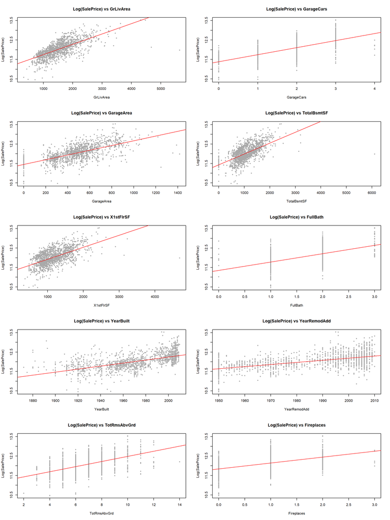

```r
top_num_vars <- names(head(num_corr, 10))

par(mfrow = c(5, 2))
for (v in top_num_vars) {
  plot(
    train_dt[[v]], train_dt$LogSalePrice,
    main = paste("Log(SalePrice) vs", v),
    xlab = v,
    ylab = "Log(SalePrice)",
    pch = 20,
    col = "darkgray"
  )
  abline(lm(train_dt$LogSalePrice ~ train_dt[[v]]), col = "red")
}
```

```r
par(mfrow = c(1,1))
```

**Observation**:

1. The scatterplots show a strong positive relationship between size-related variables and price; however, the relationship is not strictly linear.
2. Price increases slow down for very large houses, indicating diminishing marginal returns to size. This explains why size alone cannot fully account for price variation.

## 6.5 Ordinal Categorical Variables

### 6.5.1 Bar Charts

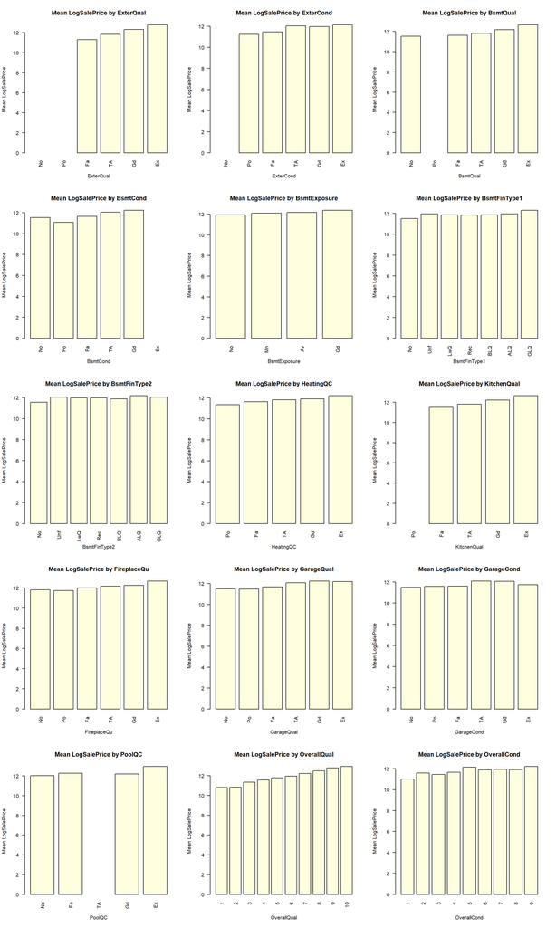

```r
par(mfrow = c(5, 3))
for (v in ordinal_vars) {
  # Calculate mean LogSalePrice for each level
  means <- tapply(train_dt$LogSalePrice, train_dt[[v]], mean, na.rm = TRUE)

  barplot(
    means,
    main = paste("Mean LogSalePrice by", v),
    xlab = v,
    ylab = "Mean LogSalePrice",
    col = "lightyellow",
    las = 2,
    border = "black"
  )
}
```

```r
par(mfrow = c(1,1))
```

### 6.5.2 Spearman Correlation

```r
ord_corr <- sapply(
  ordinal_vars,
  function(v)
    cor(
      as.numeric(train_dt[[v]]),
      train_dt$LogSalePrice,
      method = "spearman",
      use = "complete.obs"
    )
)

sort(ord_corr, decreasing = TRUE)
```

```
 OverallQual    ExterQual     BsmtQual  KitchenQual  FireplaceQu    HeatingQC
  0.80982859   0.68401380   0.67802625   0.67284855   0.53760183   0.49139191
BsmtFinType1   GarageQual   GarageCond BsmtExposure     BsmtCond       PoolQC
  0.36162475   0.35108157   0.33901490   0.31601871   0.26937252   0.05846869
BsmtFinType2    ExterCond  OverallCond
  0.03981255   0.01168189  -0.12932495
```

## 6.6 Nominal Categorical Variables

### 6.6.1 ANOVA Tests

```r
anova_results <- sapply(
  nominal_vars,
  function(v) {
    fit <- aov(LogSalePrice ~ as.factor(train_dt[[v]]), data = train_dt)
    summary(fit)[[1]]$`Pr(>F)`[1]
  }
)

anova_results <- sort(anova_results, decreasing = FALSE)
head(anova_results, 10)
```

```
 Neighborhood  GarageFinish    GarageType    MSSubClass    Foundation
4.041201e-243 4.058066e-151 8.430356e-125 5.097264e-115 1.350599e-111
   MasVnrType      MSZoning   Exterior1st   Exterior2nd    CentralAir
 6.535380e-67  1.021737e-59  1.053089e-53  2.429749e-49  9.859878e-44
```

**Interpretation**:

1.ANOVA tests whether mean SalePrice differs across categories. In particular, Neighborhood exhibits strong differences in price distribution, confirming that location introduces a structural price premium that cannot be captured by numeric variables alone.

2. Small p-values indicate strong association.

### 6.6.2 Kruskal-Wallis Tests

```r
kw_results <- sapply(
  nominal_vars,
  function(v)
    kruskal.test(train_dt$LogSalePrice ~ train_dt[[v]])$p.value
)

kw_results <- sort(kw_results)
head(kw_results, 10)
```

```
 Neighborhood  GarageFinish    GarageType    MSSubClass    Foundation
6.696799e-168 7.534250e-132 7.581344e-112 1.896860e-104 2.169096e-103
   MasVnrType      MSZoning   Exterior1st   Exterior2nd    HouseStyle
 8.799863e-60  3.080724e-57  1.694486e-56  1.047636e-51  1.388507e-36
```

**Interpretation**: Kruskal-Wallis test is non-parametric and can handle outliers well.

### 6.6.3 Boxplots of Top Nominal Variables (ANOVA)

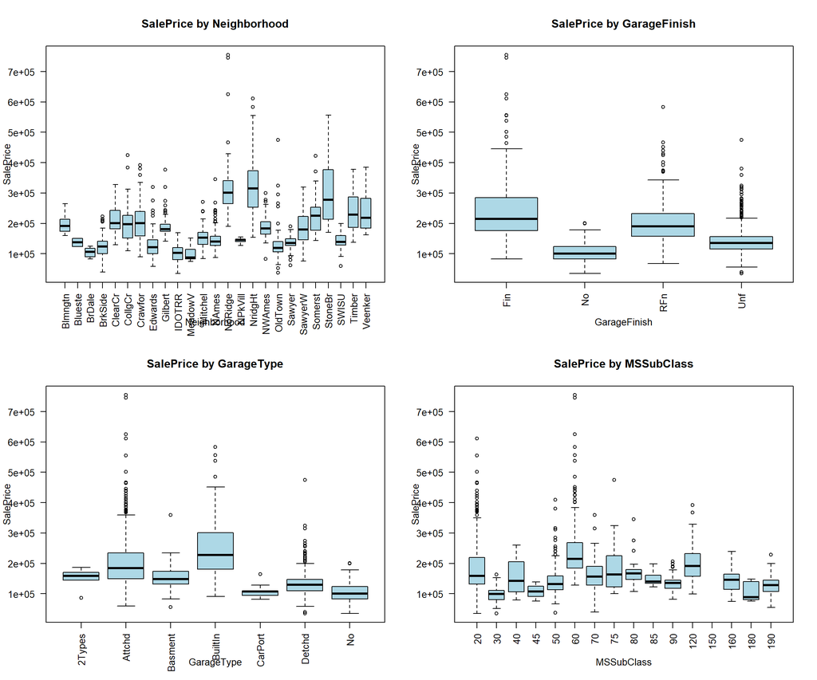

```r
top_nominal_anova <- names(head(anova_results, 4))

par(mfrow = c(2, 2))
for (v in top_nominal_anova) {
  boxplot(
    train_dt$SalePrice ~ train_dt[[v]],
    main = paste("SalePrice by", v),
    xlab = v,
    ylab = "SalePrice",
    col = "lightblue",
    las = 2,
    outline = TRUE
  )
}
```

```r
par(mfrow = c(1,1))
```

### 6.6.4 Boxplots of Top Nominal Variables (Kruskal-Wallis)

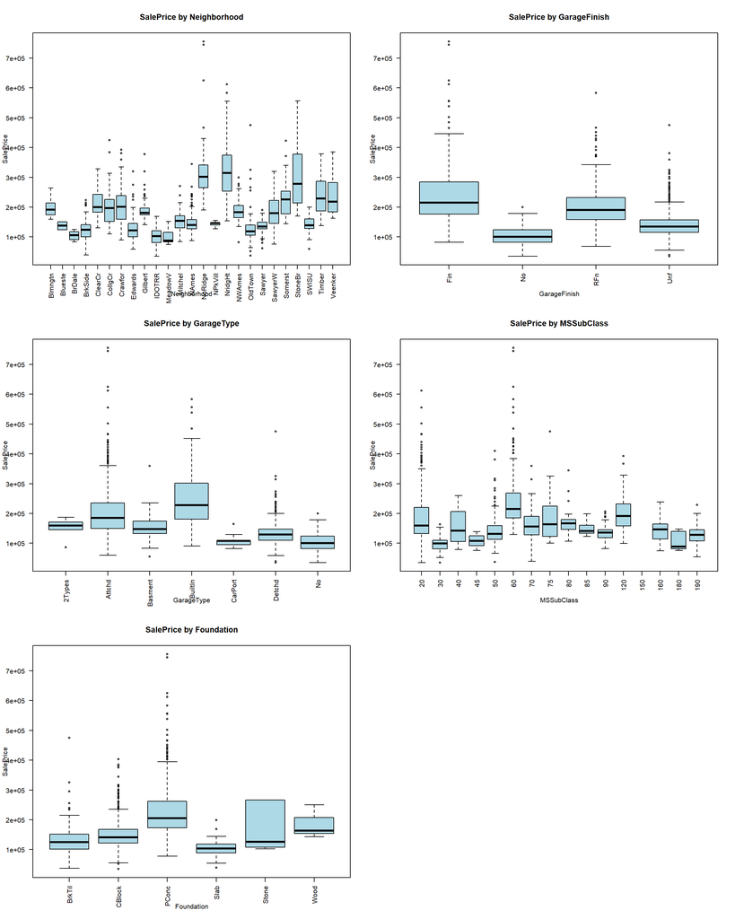

```r
top_nominal_kw <- names(head(kw_results, 5))

par(mfrow = c(3, 2))
for (v in top_nominal_kw) {
  boxplot(
    train_dt$SalePrice ~ train_dt[[v]],
    main = paste("SalePrice by", v),
    xlab = v,
    ylab = "SalePrice",
    col = "lightblue",
    las = 2,
    outline = TRUE
  )
}
par(mfrow = c(1,1))
```

## 6.7 Multicollinearity Assessment

### 6.7.1 Correlation Matrix

```r
corr_matrix <- cor(
  train_dt[numeric_continuous],
  use = "complete.obs"
)

symnum(corr_matrix)
```

```
              I LF LA YB YR MVA BFSF1 BFSF2 BU TB X1 X2 LQ GL BFB BH FB H BA K
Id            1
LotFrontage     1
LotArea            1
YearBuilt             1
YearRemodAdd          .  1
MasVnrArea            .     1
BsmtFinSF1                      1
BsmtFinSF2                            1
BsmtUnfSF                       .           1
TotalBsmtSF           .     .   .           .  1
X1stFlrSF                   .   .           .  +  1
X2ndFlrSF                                            1
LowQualFinSF                                            1
GrLivArea                   .                  .  .  ,     1
BsmtFullBath                    ,           .  .              1
BsmtHalfBath                                                      1
FullBath              .  .                     .  .  .     ,         1
HalfBath                                             ,     .            1
BedroomAbvGr                                         .     .         .    1
KitchenAbvGr                                                                 1
TotRmsAbvGrd                                      .  ,     +         .  . ,
Fireplaces                                     .  .        .
GarageYrBlt
GarageCars            .  .  .                  .  .        .         .
GarageArea            .  .  .                  .  .        .         .
WoodDeckSF
OpenPorchSF                                                .
EnclosedPorch         .
X3SsnPorch
ScreenPorch
PoolArea
MiscVal
MoSold
YrSold
              TR Fr GY GC GA W O E X3 S P MsV MS YS
Id
LotFrontage
LotArea
YearBuilt
```

[output cut: 17 more lines]

```
Fireplaces    .  1
GarageYrBlt         1
GarageCars    .  .  .  1
GarageArea    .     .  +  1
WoodDeckSF                   1
OpenPorchSF                    1
EnclosedPorch                    1
X3SsnPorch                         1
ScreenPorch                           1
PoolArea                                1
MiscVal                                   1
MoSold                                        1
YrSold                                           1
attr(,"legend")
[1] 0 ' ' 0.3 '.' 0.6 ',' 0.8 '+' 0.9 '*' 0.95 'B' 1
```

### 6.7.2 High Correlation Pairs

```r
high_corr <- data.frame(Variable1 = character(),
                        Variable2 = character(),
                        Correlation = numeric(),
                        stringsAsFactors = FALSE)

for(i in 1:nrow(corr_matrix)){
  for(j in 1:ncol(corr_matrix)){
    if(corr_matrix[i,j] > 0.5 && i > j){
      high_corr <- rbind(high_corr, data.frame(
        Variable1 = rownames(corr_matrix)[i],
        Variable2 = colnames(corr_matrix)[j],
        Correlation = corr_matrix[i, j])
      )
    }
  }
}

print(high_corr)
```

```
      Variable1    Variable2 Correlation
1  YearRemodAdd    YearBuilt   0.5928550
2   TotalBsmtSF   BsmtFinSF1   0.5223961
3     X1stFlrSF  TotalBsmtSF   0.8195300
4     GrLivArea    X1stFlrSF   0.5660240
5     GrLivArea    X2ndFlrSF   0.6875011
6  BsmtFullBath   BsmtFinSF1   0.6492118
7      FullBath    GrLivArea   0.6300116
8      HalfBath    X2ndFlrSF   0.6097073
9  BedroomAbvGr    X2ndFlrSF   0.5029006
10 BedroomAbvGr    GrLivArea   0.5212695
11 TotRmsAbvGrd    X2ndFlrSF   0.6164226
12 TotRmsAbvGrd    GrLivArea   0.8254894
13 TotRmsAbvGrd     FullBath   0.5547843
14 TotRmsAbvGrd BedroomAbvGr   0.6766199
15   GarageCars    YearBuilt   0.5378501
16   GarageCars  GarageYrBlt   0.5980046
17   GarageArea  GarageYrBlt   0.5607829
18   GarageArea   GarageCars   0.8824754
```

### 6.7.3 VIF Analysis (Initial Model)

```r
top_vars <- names(sort(num_corr, decreasing = TRUE)[1:6])

lm_base <- lm(LogSalePrice ~ .,
              data = train_dt[, c("LogSalePrice", top_vars)])

vif(lm_base)
```

```
  GrLivArea  GarageCars  GarageArea TotalBsmtSF   X1stFlrSF    FullBath
   2.144370    4.857055    4.904184    3.151767    3.577190    1.795756
```

**Interpretation**: VIF > 5 indicates unstable coefficients. Remove or combine variables if VIF is too high.

### 6.7.4 Error Analysis

```r
set.seed(123)
train_indices_caret <- createDataPartition(
  y = train_dt$LogSalePrice,
  p = 0.70,
  list = FALSE
)

# 3. Create the training dataset
train_data_caret <- train_dt[train_indices_caret, ]

# 4. Create the testing dataset
model_data_caret <- train_dt[-train_indices_caret, ]

lm1 <- lm(LogSalePrice ~ OverallQual +
            GrLivArea +
            TotalBsmtSF +
            GarageCars +
            Has_GarageYrBlt +
            KitchenQual +
            Neighborhood, data = train_data_caret)


summary(lm1)
```

```
Call:
lm(formula = LogSalePrice ~ OverallQual + GrLivArea + TotalBsmtSF +
    GarageCars + Has_GarageYrBlt + KitchenQual + Neighborhood,
    data = train_data_caret)

Residuals:
     Min       1Q   Median       3Q      Max
-1.73165 -0.07052  0.00944  0.08886  0.49651

Coefficients:
                      Estimate Std. Error t value Pr(>|t|)
(Intercept)          1.084e+01  6.396e-02 169.431  < 2e-16 ***
OverallQual          8.639e-02  6.406e-03  13.487  < 2e-16 ***
GrLivArea            2.065e-04  1.339e-05  15.426  < 2e-16 ***
TotalBsmtSF          8.872e-05  1.427e-05   6.219 7.36e-10 ***
GarageCars           7.543e-02  1.087e-02   6.938 7.15e-12 ***
Has_GarageYrBlt      5.777e-02  2.852e-02   2.026 0.043054 *
KitchenQual.L        1.666e-01  2.805e-02   5.941 3.92e-09 ***
KitchenQual.Q        8.737e-03  1.942e-02   0.450 0.652861
KitchenQual.C       -9.224e-03  1.119e-02  -0.824 0.410042
NeighborhoodBlueste -3.417e-02  1.219e-01  -0.280 0.779264
NeighborhoodBrDale  -1.707e-01  6.780e-02  -2.518 0.011952 *
NeighborhoodBrkSide -8.076e-03  5.648e-02  -0.143 0.886335
NeighborhoodClearCr  2.435e-01  6.217e-02   3.916 9.62e-05 ***
NeighborhoodCollgCr  1.087e-01  4.999e-02   2.175 0.029845 *
NeighborhoodCrawfor  1.984e-01  5.587e-02   3.551 0.000401 ***
NeighborhoodEdwards -1.647e-02  5.342e-02  -0.308 0.757944
NeighborhoodGilbert  1.153e-01  5.302e-02   2.175 0.029846 *
NeighborhoodIDOTRR  -2.336e-01  5.975e-02  -3.910 9.87e-05 ***
NeighborhoodMeadowV -9.987e-02  6.828e-02  -1.463 0.143840
NeighborhoodMitchel  8.716e-02  5.588e-02   1.560 0.119113
NeighborhoodNAmes    6.336e-02  5.096e-02   1.243 0.214041
NeighborhoodNoRidge  2.126e-01  5.681e-02   3.741 0.000193 ***
NeighborhoodNPkVill -1.537e-02  8.590e-02  -0.179 0.858016
NeighborhoodNridgHt  1.757e-01  5.261e-02   3.339 0.000873 ***
NeighborhoodNWAmes   8.418e-02  5.356e-02   1.572 0.116305
NeighborhoodOldTown -1.097e-01  5.299e-02  -2.070 0.038691 *
NeighborhoodSawyer   5.272e-02  5.462e-02   0.965 0.334624
NeighborhoodSawyerW  6.707e-02  5.438e-02   1.233 0.217694
NeighborhoodSomerst  1.343e-01  5.174e-02   2.595 0.009603 **
NeighborhoodStoneBr  1.874e-01  6.213e-02   3.016 0.002624 **
NeighborhoodSWISU   -1.114e-02  6.370e-02  -0.175 0.861160
NeighborhoodTimber   1.449e-01  5.794e-02   2.500 0.012573 *
NeighborhoodVeenker  2.557e-01  7.099e-02   3.602 0.000332 ***
---
Signif. codes:  0 '***' 0.001 '**' 0.01 '*' 0.05 '.' 0.1 ' ' 1

Residual standard error: 0.1572 on 991 degrees of freedom
Multiple R-squared:  0.8541,    Adjusted R-squared:  0.8494
F-statistic: 181.3 on 32 and 991 DF,  p-value: < 2.2e-16
```

```r
# Predictions on test data
model_data_caret$pred_LogSalePrice <- predict(
  lm1,
  newdata = model_data_caret
)

# Convert back to original price scale
model_data_caret$pred_SalePrice <- exp(model_data_caret$pred_LogSalePrice)
model_data_caret$actual_SalePrice <- exp(model_data_caret$LogSalePrice)

# Error terms
model_data_caret$error <- model_data_caret$actual_SalePrice -
  model_data_caret$pred_SalePrice

model_data_caret$abs_error <- abs(model_data_caret$error)

model_data_caret$perc_error <-
  100 * model_data_caret$abs_error / model_data_caret$actual_SalePrice

MAE  <- mean(model_data_caret$abs_error)
RMSE <- sqrt(mean(model_data_caret$error^2))
MAPE <- mean(model_data_caret$perc_error)

MAE  # MAE reflects typical absolute error
```

```
[1] 20574.46
```

```r
RMSE #RMSE penalizes large errors more strongly
```

```
[1] 36501.93
```

```r
MAPE #MAPE expresses error in percentage terms, making it scale-independent.
```

```
[1] 11.46566
```

**Observation**: The model achieves an average absolute error of approximately $20,574.46 and a mean absolute percentage error of about 11.5%. While some large errors remain for extreme-priced houses,overall performance is reasonable and consistent with the inherent variability of the housing market.

**Remark**: MAE represents the typical prediction error, while RMSE penalizes large deviations more heavily.The higher RMSE relative to MAE indicates that a small number of extreme-priced houses contribute disproportionately to prediction error.MAPE shows that, on average, predictions are within approximately 10–12% of actual prices

[output not shown]

# 7 Final Model

## 7.1 Model Specification

```r
final_model <- lm(
  LogSalePrice ~
    OverallQual +
    GrLivArea +
    TotalBsmtSF +
    GarageCars +
    Has_GarageYrBlt +
    KitchenQual +
    Neighborhood,
  data = train_dt
)

summary(final_model)
```

```
Call:
lm(formula = LogSalePrice ~ OverallQual + GrLivArea + TotalBsmtSF +
    GarageCars + Has_GarageYrBlt + KitchenQual + Neighborhood,
    data = train_dt)

Residuals:
     Min       1Q   Median       3Q      Max
-1.77199 -0.06697  0.01131  0.08773  0.51380

Coefficients:
                      Estimate Std. Error t value Pr(>|t|)
(Intercept)          1.089e+01  5.292e-02 205.850  < 2e-16 ***
OverallQual          8.323e-02  5.418e-03  15.362  < 2e-16 ***
GrLivArea            2.111e-04  1.117e-05  18.892  < 2e-16 ***
TotalBsmtSF          1.012e-04  1.224e-05   8.270 3.03e-16 ***
GarageCars           6.615e-02  9.206e-03   7.186 1.07e-12 ***
Has_GarageYrBlt      4.488e-02  2.344e-02   1.914 0.055778 .
KitchenQual.L        1.687e-01  2.426e-02   6.954 5.39e-12 ***
KitchenQual.Q       -3.694e-03  1.665e-02  -0.222 0.824416
KitchenQual.C        3.712e-03  9.438e-03   0.393 0.694190
NeighborhoodBlueste -6.981e-02  1.177e-01  -0.593 0.553123
NeighborhoodBrDale  -2.080e-01  5.638e-02  -3.690 0.000233 ***
NeighborhoodBrkSide -4.486e-02  4.534e-02  -0.990 0.322564
NeighborhoodClearCr  1.870e-01  4.935e-02   3.789 0.000158 ***
NeighborhoodCollgCr  8.224e-02  4.028e-02   2.042 0.041346 *
NeighborhoodCrawfor  1.553e-01  4.523e-02   3.433 0.000613 ***
NeighborhoodEdwards -7.080e-02  4.322e-02  -1.638 0.101660
NeighborhoodGilbert  9.196e-02  4.265e-02   2.156 0.031236 *
NeighborhoodIDOTRR  -2.244e-01  4.817e-02  -4.659 3.48e-06 ***
NeighborhoodMeadowV -1.512e-01  5.605e-02  -2.698 0.007065 **
NeighborhoodMitchel  4.984e-02  4.519e-02   1.103 0.270240
NeighborhoodNAmes    2.199e-02  4.114e-02   0.535 0.593054
NeighborhoodNoRidge  1.807e-01  4.634e-02   3.900 0.000101 ***
NeighborhoodNPkVill -3.807e-02  6.531e-02  -0.583 0.560007
NeighborhoodNridgHt  1.746e-01  4.287e-02   4.072 4.92e-05 ***
NeighborhoodNWAmes   5.589e-02  4.320e-02   1.294 0.195897
NeighborhoodOldTown -1.531e-01  4.270e-02  -3.585 0.000349 ***
NeighborhoodSawyer   2.846e-02  4.401e-02   0.647 0.517870
NeighborhoodSawyerW  4.168e-02  4.366e-02   0.955 0.339844
NeighborhoodSomerst  1.021e-01  4.169e-02   2.449 0.014461 *
NeighborhoodStoneBr  1.931e-01  4.965e-02   3.890 0.000105 ***
NeighborhoodSWISU   -4.681e-02  5.188e-02  -0.902 0.367067
NeighborhoodTimber   1.367e-01  4.590e-02   2.979 0.002942 **
NeighborhoodVeenker  2.226e-01  6.082e-02   3.660 0.000262 ***
---
Signif. codes:  0 '***' 0.001 '**' 0.01 '*' 0.05 '.' 0.1 ' ' 1

Residual standard error: 0.1564 on 1427 degrees of freedom
Multiple R-squared:   0.85, Adjusted R-squared:  0.8466
F-statistic: 252.7 on 32 and 1427 DF,  p-value: < 2.2e-16
```

## 7.2 Model Diagnostics

### 7.2.1 VIF for Final Model

```r
vif(final_model)
```

```
                    GVIF Df GVIF^(1/(2*Df))
OverallQual     3.347580  1        1.829639
GrLivArea       2.055638  1        1.433750
TotalBsmtSF     1.719065  1        1.311131
GarageCars      2.822043  1        1.679894
Has_GarageYrBlt 1.718312  1        1.310844
KitchenQual     2.915853  3        1.195256
Neighborhood    5.083825 24        1.034457
```

### 7.2.2 Diagnostic Plots

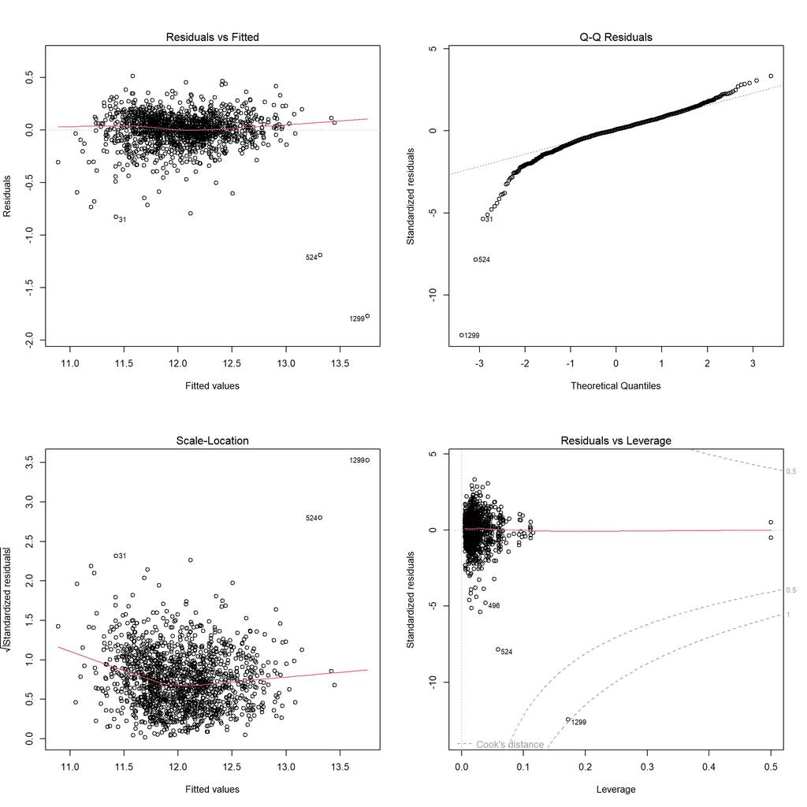

```r
par(mfrow = c(2, 2))
plot(final_model)
```

```r
par(mfrow = c(1, 1))
```

**Interpretation:**

- **Residuals vs Fitted**: Random scatter indicates good linear fit
- **Normal Q-Q**: Points should follow diagonal line for normality
- **Scale-Location**: Horizontal line suggests constant variance (homoscedasticity)
- **Residuals vs Leverage**: Identifies influential observations

# 8 Predictions

## 8.1 Handling Missing Values in Test Set

**Rationale**: Prediction errors caused by missing values were resolved by restricting imputation to common variables between training and test datasets and aligning factor levels prior to prediction.

```r
# Align factor levels between train and test
for (col in names(train_dt)) {
  if (is.factor(train_dt[[col]])) {
    levels(test_dt[[col]]) <- levels(train_dt[[col]])
  }
}
```

```r
# Median imputation for numeric variables
numeric_common <- intersect(numeric_continuous, names(test_dt))

for (col in numeric_common) {
  med_val <- median(train_dt[[col]], na.rm = TRUE)
  test_dt[[col]][is.na(test_dt[[col]])] <- med_val
}
```

```r
# Mode imputation for categorical variables
cat_vars <- names(train_dt)[sapply(train_dt, is.factor)]
cat_common <- intersect(cat_vars, names(test_dt))

get_mode <- function(x) {
  ux <- na.omit(unique(x))
  ux[which.max(tabulate(match(x, ux)))]
}

for (col in cat_common) {
  mode_val <- get_mode(train_dt[[col]])
  test_dt[[col]][is.na(test_dt[[col]])] <- mode_val
}

# Ensure factor levels align
for (col in cat_common) {
  levels(test_dt[[col]]) <- levels(train_dt[[col]])
}
```

## 8.2 Generate Predictions on Test Set

```r
test_dt$LogSalePrice_pred <- predict(final_model, newdata = test_dt)
test_dt$SalePrice_pred <- expm1(test_dt$LogSalePrice_pred)

summary(test_dt$SalePrice_pred)
```

```
   Min. 1st Qu.  Median    Mean 3rd Qu.    Max.
  58073  126070  157929  176731  207036  808443
```

## 8.3 Prediction Distribution

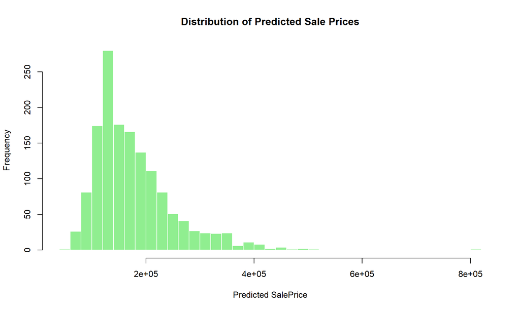

```r
hist(
  test_dt$SalePrice_pred,
  breaks = 40,
  col = "lightgreen",
  main = "Distribution of Predicted Sale Prices",
  xlab = "Predicted SalePrice",
  border = "white"
)
```

**Interpretation** As expected distribution of predicted sale prices in also right skewed showing that there will be fewer houses with higher prices.

# 9 Conclusions

- Model assumes linear relationships in log-transformed space
- Categorical variables with many levels may benefit from regularization
- Temporal dynamics not fully exploited
- Interaction effects between predictors not explored

## 9.3 Future Work

1. Explore advanced models: Ridge, Lasso, Random Forest, Gradient Boosting
2. Create interaction terms and polynomial features
3. Implement cross-validation for robust performance assessment
4. Incorporate time-series elements for market trends
5. Use geospatial techniques for neighborhood effects

## 9.4 Practical Implications

Housing prices in Ames, Iowa are primarily driven by quality, size, and location. This provides insights for:

- **Homebuyers**: Prioritize overall quality and living space
- **Sellers**: Kitchen quality and basement improvements yield returns
- **Appraisers**: Data-driven valuation framework
- **Policy Makers**: Understanding housing market dynamics